# Using random forests to understand the drivers of nutrients in constrasting coastal ecosystems

## Methods

Data was collected from each station, preparation for analysis with the programming language R, and merged together with emphasis on maintaining the highest sample size. The highest sample size was our priority because it allows us to obtain the most amount of true values to train and test the random forest models.

We compared two well known implementations of the random forest architecture: randomForest and ranger. The package randomForest is based on the Brieman’s Random Forest implementation, while ranger uses a combination of methodologies to emphasize speed and memory efficiency.

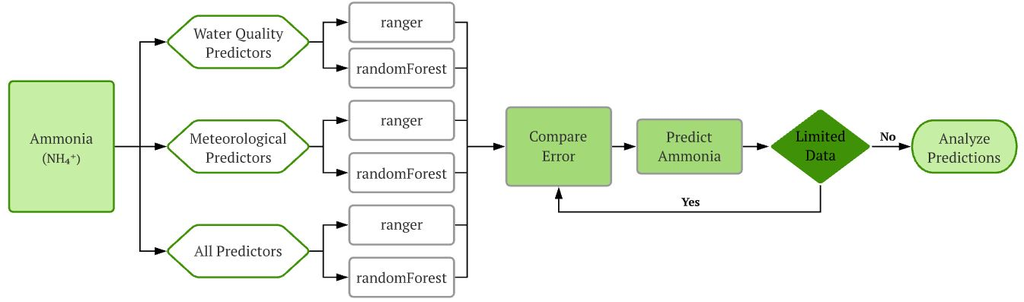

Figure 2. Overview of ammonia random forest model training procedure.

To give stronger evidence that we are on the right assumptions we evaluated the correlation between predictors and known nutrient information (Figure 3).

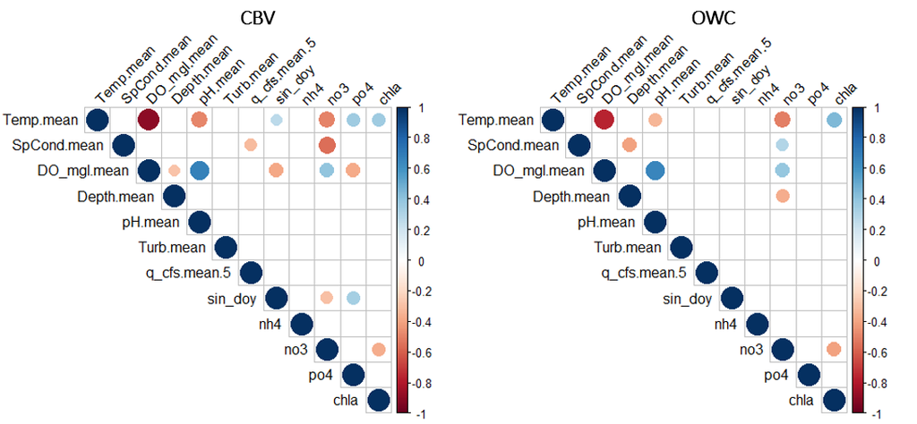

Figure 3. Correlations of original data

### Model Training

1. Single line of code to train and get model information needed for analysis and new plots:

```r
#Train data on cbv location with random forest
result_cbv_rf <- parApply(cl,reference_table,1,
                          function(x) choose_inputs(
                            cbv_all,
                            x[1],
                            eval(parse(text = x[2])),
                            x[3],
                            modelType = "randomForest",
                            importance = TRUE,
                            prop = 8/10))
```

2. The steps to Train a model:

```r
# Create model, and return useful things (data, plots, stats)
choose_inputs <- function(all_data, dep, pred, label, importance, prop = 3/4, t = -1, modelType = "ranger", station = "") {
  #Clean and filter data set
  dt_clean <- all_data %>%
    select(all_of(dep), all_of(pred)) %>%
    drop_na() %>%
    rename(actual = all_of(dep))

  #Calculate correlations
  correlations <- cor(dt_clean)

  dt_split <- splitData(dt_clean, dep, pred, prop)

  #Create the train and test data
  dt_train <- training(dt_split)
  dt_test <- testing(dt_split)

  # create CV object from training data
  dt_cv <- vfold_cv(dt_train)

  #1. Create the Recipe
  dt_recipe <- createRecipe(dt_train, dt_clean)

  #2. Specify the Model
  rf_model <- specifyModel(modelType, t, importance)

  #3. Create workflow
  rf_workflow <- createWorkflow(dt_recipe, rf_model)

  #4. Tune mtry
  rf_workflow <- tuneMtry(rf_workflow, pred, dt_cv, t)

  #6. Fit model to train set and validate on test set
  rf_fit <- rf_workflow %>%
    # fit on the training set and evaluate on test set
    last_fit(dt_split)


  #7. Evaluate model performance
  test_predictions <- rf_fit %>% collect_predictions()
  all_metrics <- evaluateModel(rf_fit, test_predictions)

  #8. Build Figure
  Fig <- showEval(test_predictions, label)

  #9. Build Final Model
  final_model <- fit(rf_workflow, dt_clean)


      #(Optional) built explainer to work with DALEX for neural networks
      explainer_rf<- explain_tidymodels(
        final_model,
        data = dplyr::select(dt_clean, -actual),
        y = dt_clean$actual,
        label = "random forest"
      )

  #10. Build importance plots
  importance <- grabTheImportance(final_model, modelType)
  importancePlot <- createImportancePlot(importance, paste0(dep,": ", station))

  #Return a list of the ggplot figure, the final fit, the best mtry,
  #and the mtry at each fold
  Fig_result <- list(Fig,
                     final_model,
                     rf_fit,
                     all_metrics,
                     correlations,
                     importancePlot,
                     explainer_rf)

  names(Fig_result) <- c("plot",
                         "finalModel",
                         "trainTestModel",
                         "metrics",
                         "correlations",
                         "importancePlot",
                         "finalModelDT")
  return(Fig_result)
}
```

## Feature Importance

With random forests, unlike other “black-box” machine learning methods, such as artificial neural networks (ANNs), we can find feature importance in regards to how the model predicted values. This is a big advantage when it comes to when we want to know how significant values are found and give a better understanding of the roles of different features in an ecosystem.

> Gini Importance is calculated as the decrease in node impurity weighted by the probability of reaching that node. The node probability can be calculated by the number of samples that reach the node, divided by the total number of samples. The higher the value the more important the feature." - [Stacy Ronaghan](https://towardsdatascience.com/the-mathematics-of-decision-trees-random-forest-and-feature-importance-in-scikit-learn-and-spark-f2861df67e3)

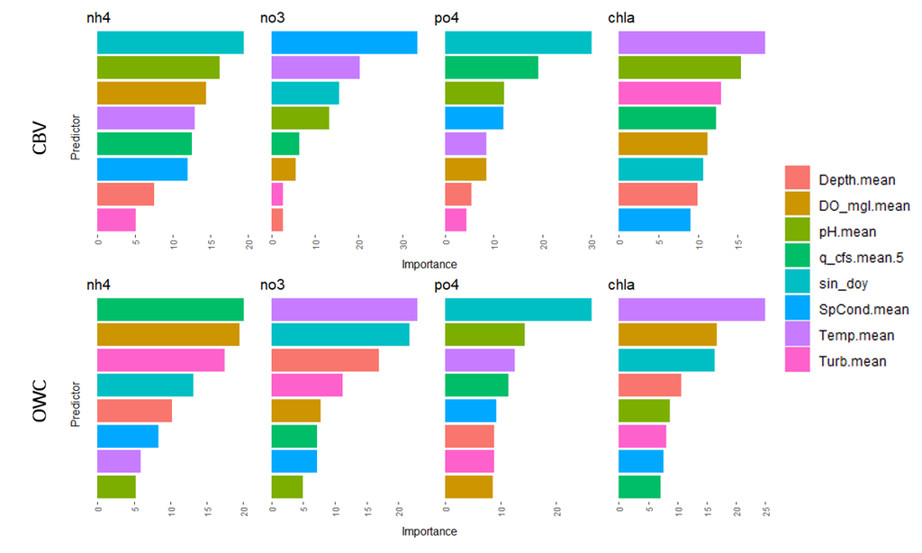

Figure 5. Feature importance as a percentage of gini importance.

## Nutrient Patterns

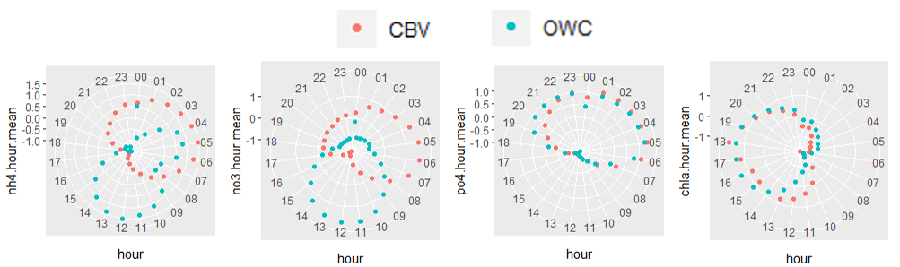

Figure 8. Polar plots of nutrient patterns by the hour

## Hurricanes and Tropical Storms

In addition to general patterns we can explore specific events now, where as before we had only a fraction of the amount of nutrient data information. Now, we can observe specific storm events and explore the drivers that influenced nutrient levels to change or stay the same. As we delve deeper in the data, you can see significant events happening. Below are three hurricanes that hit Chesapeake Bay with varying intensity:

1. Hurricane Isabelle
2. Tropical Storm Melissa
3. Hurricane Irene

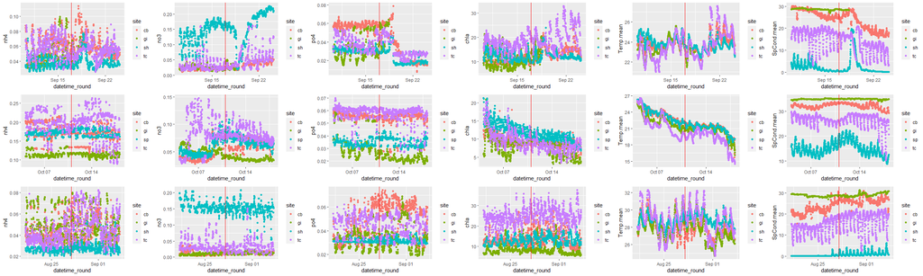

Figure 11. Hurricane events

## Seiche Events

As opposed to our salt water counterpart in the Chesapeake Bay, Lake Erie does not get these storm systems. Instead, we can look at a strange phenomenon known as a seiche event. A seiche is when a strong west to east wind is prevalent and pushes water up to one side of the lake and recedes from the other. In Lake Erie, it has been reported to cause tidal changes of up to 15 ft. This causes a great mixing of the water both from the physical movement and underwater waves that mix benthic water to the surface.

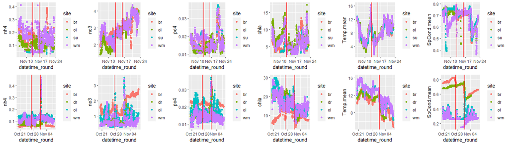

Figure 12. Seiche events

## References

Breiman, L. Random Forests. Machine Learning 45, 5–32 (2001). https://doi.org/10.1023/A:1010933404324

Wright, M.N., and Ziegler, A. ranger: A Fast Implementation of Random Forests for High Deimensional Data in C++ and R. 77, 1 (2017). https://doi.org/10.18637/jss.v077.i01

# Suplemental Information

## Feature Selection

| Signal | Predictor | ranger CBV MAE | ranger CBV RMSE | ranger CBV NSE | ranger OWC MAE | ranger OWC RMSE | ranger OWC NSE | randomForest CBV MAE | randomForest CBV RMSE | randomForest CBV NSE | randomForest OWC MAE | randomForest OWC RMSE | randomForest OWC NSE |
| --- | --- | --- | --- | --- | --- | --- | --- | --- | --- | --- | --- | --- | --- |
| nh4 | met | 0.02 | 0.04 | 0.44 | 0.06 | 0.09 | 0.54 | 0.02 | 0.03 | 0.54 | 0.05 | 0.08 | 0.63 |
| nh4 | wq | 0.02 | 0.03 | 0.60 | 0.05 | 0.06 | 0.78 | 0.02 | 0.03 | 0.65 | 0.04 | 0.06 | 0.83 |
| nh4 | all | 0.02 | 0.03 | 0.59 | 0.06 | 0.09 | 0.67 | 0.02 | 0.03 | 0.67 | 0.05 | 0.08 | 0.73 |
| po4 | met | 0.01 | 0.01 | 0.63 | 0.01 | 0.01 | 0.32 | 0.01 | 0.01 | 0.63 | 0.01 | 0.01 | 0.39 |
| po4 | wq | 0.01 | 0.01 | 0.74 | 0.01 | 0.01 | 0.47 | 0.01 | 0.01 | 0.74 | 0.00 | 0.01 | 0.53 |
| po4 | all | 0.01 | 0.01 | 0.73 | 0.00 | 0.01 | 0.50 | 0.01 | 0.01 | 0.76 | 0.00 | 0.01 | 0.53 |
| no3 | met | 0.04 | 0.06 | 0.48 | 0.57 | 0.98 | 0.62 | 0.03 | 0.06 | 0.57 | 0.48 | 0.90 | 0.68 |
| no3 | wq | 0.03 | 0.04 | 0.78 | 0.49 | 0.80 | 0.73 | 0.03 | 0.04 | 0.78 | 0.42 | 0.76 | 0.75 |
| no3 | all | 0.03 | 0.04 | 0.80 | 0.63 | 1.03 | 0.63 | 0.03 | 0.04 | 0.76 | 0.56 | 0.96 | 0.68 |
| chla | met | 7.14 | 10.16 | 0.39 | 9.92 | 17.64 | 0.56 | 6.61 | 10.54 | 0.50 | 8.31 | 16.37 | 0.62 |
| chla | wq | 6.71 | 10.58 | 0.47 | 6.35 | 10.27 | 0.74 | 6.70 | 12.17 | 0.55 | 5.63 | 9.32 | 0.79 |
| chla | all | 6.51 | 9.78 | 0.46 | 6.49 | 9.83 | 0.80 | 5.94 | 10.47 | 0.61 | 5.52 | 9.04 | 0.83 |

## Missing Predictions

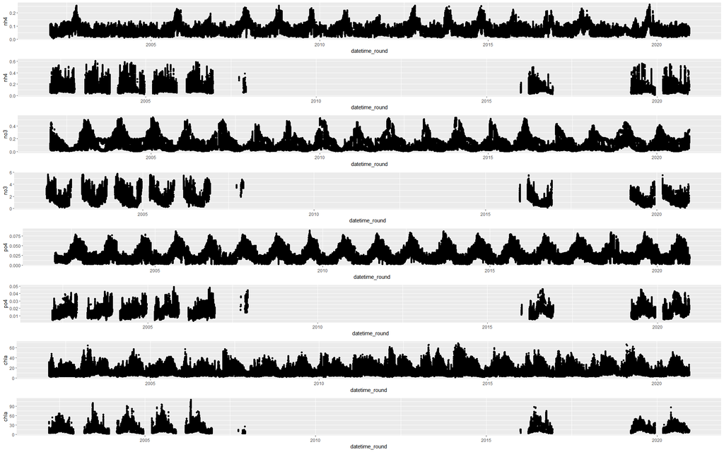

SI Figure 2. High frequency predictions

## Architecture Selection

| Signal | Predictor | ranger CBV MAE | ranger CBV RMSE | ranger CBV NSE | ranger OWC MAE | ranger OWC RMSE | ranger OWC NSE | randomForest CBV MAE | randomForest CBV RMSE | randomForest CBV NSE | randomForest OWC MAE | randomForest OWC RMSE | randomForest OWC NSE |
| --- | --- | --- | --- | --- | --- | --- | --- | --- | --- | --- | --- | --- | --- |
| nh4 | wq | 0.02 | 0.03 | 0.60 | 0.05 | 0.06 | 0.78 | 0.02 | 0.03 | 0.65 | 0.04 | 0.06 | 0.83 |
| po4 | wq | 0.01 | 0.01 | 0.74 | 0.01 | 0.01 | 0.47 | 0.01 | 0.01 | 0.74 | 0.00 | 0.01 | 0.53 |
| no3 | wq | 0.03 | 0.04 | 0.78 | 0.49 | 0.80 | 0.73 | 0.03 | 0.04 | 0.78 | 0.42 | 0.76 | 0.75 |
| chla | wq | 6.71 | 10.58 | 0.47 | 6.35 | 10.27 | 0.74 | 6.70 | 12.17 | 0.55 | 5.63 | 9.32 | 0.79 |

## Model Performance

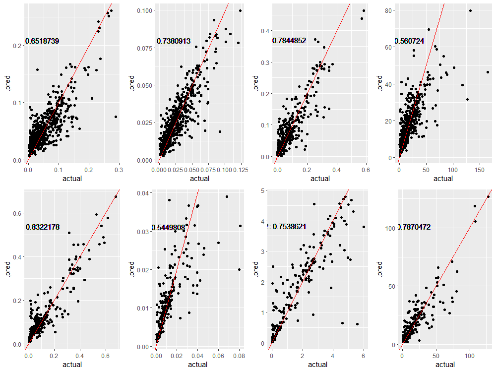

SI Figure 4. Actual versus predicted plots

## Partial Dependency Plots

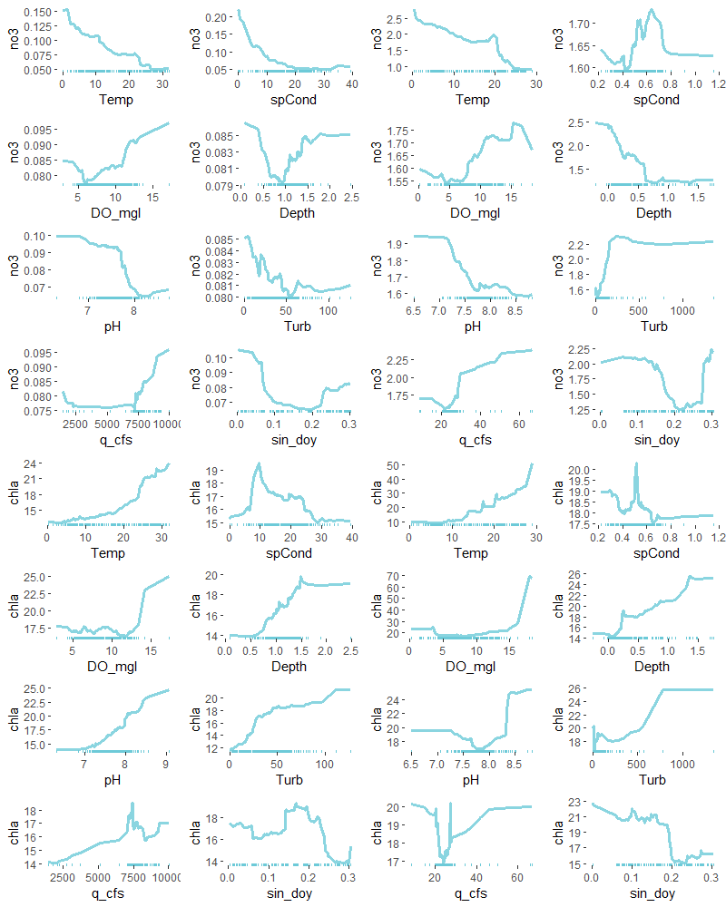

SI Figure 5. Partial dependency plots

## Monthly Patterns

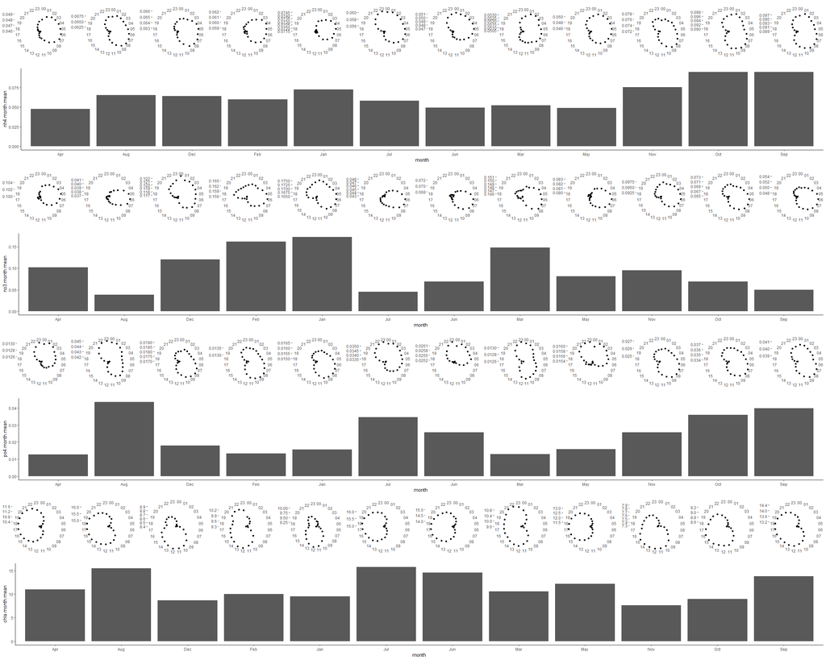

SI Figure 6. CBV nutrient patterns by month

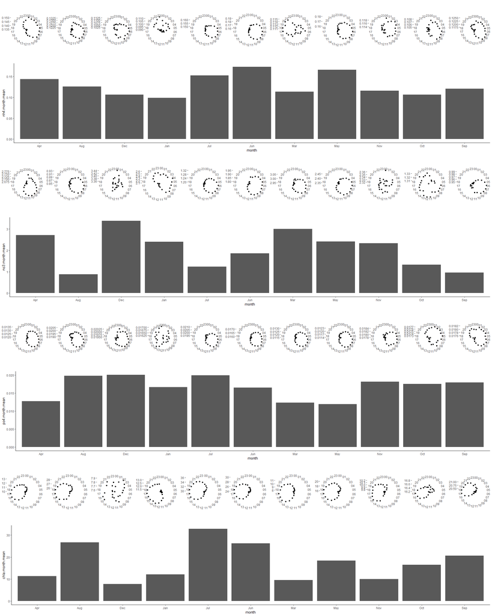

SI Figure 7. OWC nutrient patterns by month